# Danio_rerio_bioanalyzer_in-vivo_rRNA_integrity_v1

AJ Treichel

2025-01-27

#### Loading custom functions for the analysis pipeline

```r
source(here("functions/250127_bioanalyzer_analysis_functions.R"))
```

### This notebook takes a whole directory as input that contains “*Ladder\.csv” file along with ”Sample.*\.csv” files, and an “info.*\.csv” from a single bioanalyzer chip.

The ‘test_data’ folder is an example that you can use to test this script.

```r
# Specify your input directory
input_dir <- here("test_data")
# Specify your output directory
output_dir <- here('test_output_1')
# Making the output directory if it doesn't exist
if (!dir.exists(output_dir)) {
    dir.create(output_dir, recursive = TRUE)
}
```

#### It is a good idea to run the ba.fitladder() function first in order to make sure your ladder fit is good. Some ladder runs are noisier than others and you may need to adjust the parameters here

```r
ba.fitladder(input_dir)
```

```
##
## Call:
## lm(formula = lad_peaks_df$size_nt ~ poly(lad_peaks_df$time, degree = 2,
##     raw = TRUE))
##
## Residuals:
##       1       2       3       4       5       6       7
##  -6.544  21.458  30.433 -56.964 -54.190 113.102 -47.295
##
## Coefficients:
##                                                   Estimate Std. Error t value
## (Intercept)                                      2596.4843   359.9723   7.213
## poly(lad_peaks_df$time, degree = 2, raw = TRUE)1 -222.2953    18.7699 -11.843
## poly(lad_peaks_df$time, degree = 2, raw = TRUE)2    4.8132     0.2289  21.027
##                                                  Pr(>|t|)
## (Intercept)                                      0.001959 **
## poly(lad_peaks_df$time, degree = 2, raw = TRUE)1 0.000291 ***
## poly(lad_peaks_df$time, degree = 2, raw = TRUE)2 3.02e-05 ***
## ---
## Signif. codes:  0 '***' 0.001 '**' 0.01 '*' 0.05 '.' 0.1 ' ' 1
##
## Residual standard error: 75.23 on 4 degrees of freedom
## Multiple R-squared:  0.9993, Adjusted R-squared:  0.9989
## F-statistic:  2682 on 2 and 4 DF,  p-value: 5.554e-07
```

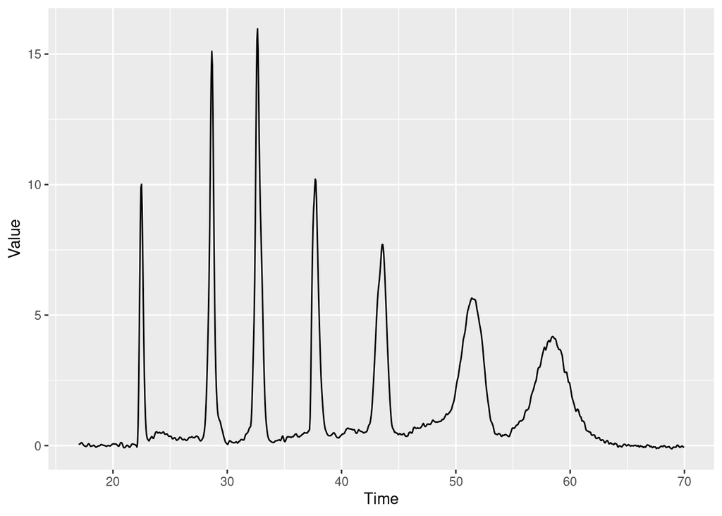

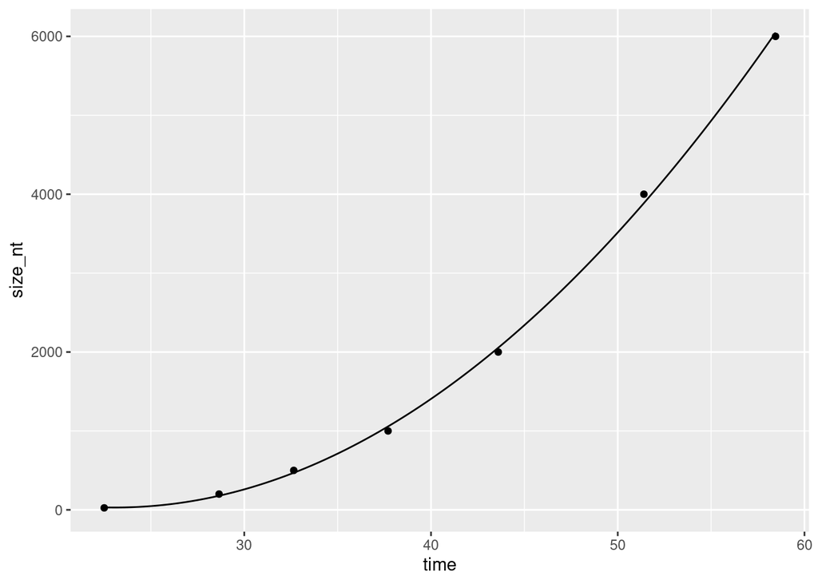

```
##                                      (Intercept)
##                                      2596.484310
## poly(lad_peaks_df$time, degree = 2, raw = TRUE)1
##                                      -222.295255
## poly(lad_peaks_df$time, degree = 2, raw = TRUE)2
##                                         4.813241
```

### Okay, so in the test data, the ladder fit is appropriate. Now we move on to naming, calibrating, normalizing, and trimming the traces.

```r
trace_data <- ba.cal_trim_csv(directory = input_dir, output_path = output_dir)
```

```r
head(trace_data)
```

```
##      Time  size_nt pcas13d_4hpf_n1_2 pcas13d_4hpf_n3_1 pcas13d_guideRNA2_n2_1
## 141 24.00 33.82493       0.004604589       0.003188253            0.004313157
## 142 24.05 34.27398       0.004738628       0.003360384            0.003865671
## 143 24.10 34.74709       0.004022475       0.003245139            0.003435917
## 144 24.15 35.24427       0.003109738       0.002793974            0.003335637
## 145 24.20 35.76552       0.002291011       0.002450111            0.003034409
## 146 24.25 36.31083       0.002068287       0.002277380            0.003549297
##     pcas13d_guideRNA2_n3_1 pcas13d_guideRNA3_n1_2 pcas13d_guideRNA3_n2_1
## 141            0.003091506            0.003504227            0.005044365
## 142            0.003078779            0.004026143            0.005226425
## 143            0.003065618            0.003921843            0.005627602
## 144            0.002919151            0.004153028            0.005996993
## 145            0.003015448            0.004382578            0.006356875
## 146            0.002824222            0.004861344            0.005911776
##     pcas13d_guideRNA1_n2_1 pcas13d_guideRNA1_n3_1
## 141            0.003494465            0.003353346
## 142            0.003918988            0.003126813
## 143            0.004158573            0.002789392
## 144            0.004379201            0.003023107
## 145            0.004265958            0.003779166
## 146            0.004371646            0.004315315
```

### Now we can plot these traces to see if we have any funny business going on.

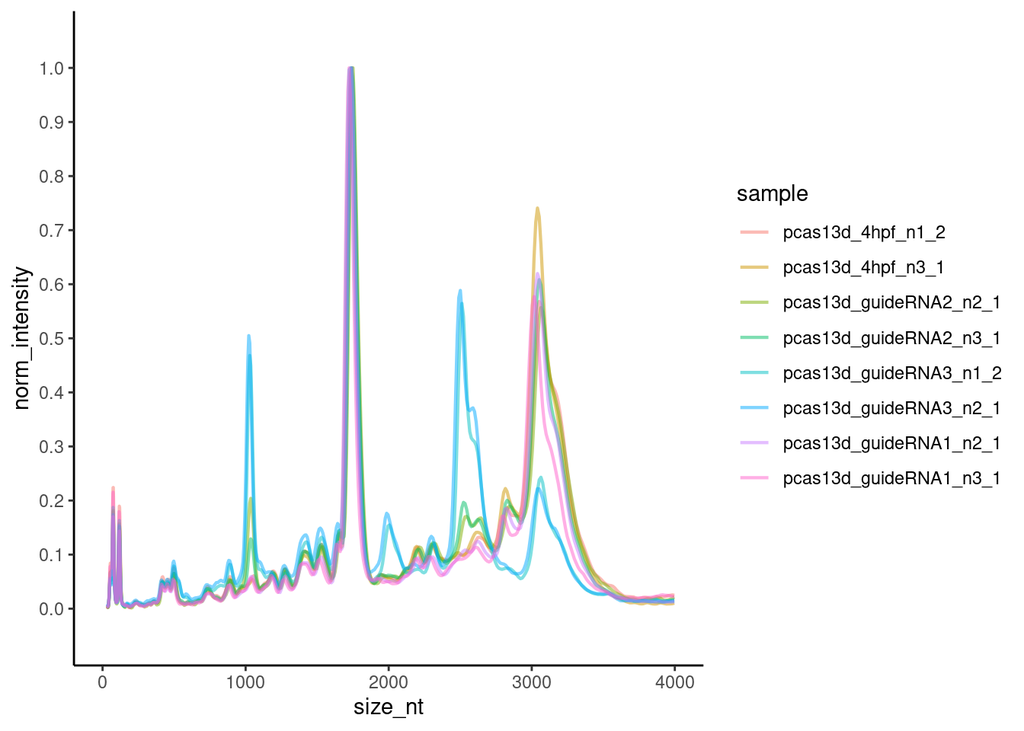

```r
trace_data %>%
  reshape2::melt(., id.vars = c('Time', 'size_nt'), value.name = 'norm_intensity', variable.name = 'sample') %>%
  ggplot(aes( x = size_nt, y = norm_intensity, color = sample, group = sample))+
  geom_line(linewidth = 0.75, alpha = 0.5)+
  scale_x_continuous(limits = c(0, 4000), breaks = seq(0,4000, by = 1000))+
  scale_y_continuous(limits = c(-0.05, 1.05), breaks = seq(0,1, by = 0.1))+
  theme_classic()
```

### Now that we have all of our traces identified and processed, we can find & analyze the 18S rRNA, 28S rRNA, and potential 28S rRNA cleavage peak(s) in it. THIS REQUIRES NORMALIZED TRACES AS INPUT

#### It is a good first step to test whether you can detect any peaks with the pipeline using the ba.analyze_rrna_list_only() command. You may need to adjust the default parameters if the traces are shifted and/or noisy compared to the output that this pipeline was developed with.

```r
ba.analyze_rrna_list_only(trace_data)
```

```
## $pcas13d_4hpf_n1_2
##           [,1] [,2] [,3] [,4]
## [1,] 1.0000000  360  353  377
## [2,] 0.5679919  484  473  539
##
## $pcas13d_4hpf_n3_1
##           [,1] [,2] [,3] [,4]
## [1,] 1.0000000  360  352  376
## [2,] 0.7408205  483  472  534
##
## $pcas13d_guideRNA2_n2_1
##           [,1] [,2] [,3] [,4]
## [1,] 0.2039446  272  258  282
## [2,] 1.0000000  361  353  377
## [3,] 0.1705736  440  427  444
## [4,] 0.5567647  485  473  535
##
## $pcas13d_guideRNA2_n3_1
##           [,1] [,2] [,3] [,4]
## [1,] 1.0000000  360  353  377
## [2,] 0.1965508  438  425  443
## [3,] 0.6083458  484  473  538
##
## $pcas13d_guideRNA3_n1_2
##           [,1] [,2] [,3] [,4]
## [1,] 0.4681713  271  258  287
## [2,] 1.0000000  360  353  375
## [3,] 0.5643941  437  425  462
## [4,] 0.2429656  485  473  520
##
## $pcas13d_guideRNA3_n2_1
##           [,1] [,2] [,3] [,4]
## [1,] 0.5049192  270  257  287
## [2,] 1.0000000  359  351  374
## [3,] 0.5884332  436  424  442
## [4,] 0.2218994  483  471  517
##
## $pcas13d_guideRNA1_n2_1
##           [,1] [,2] [,3] [,4]
## [1,] 1.0000000  360  352  377
## [2,] 0.6196628  483  472  535
##
## $pcas13d_guideRNA1_n3_1
##           [,1] [,2] [,3] [,4]
## [1,] 1.0000000  358  351  375
## [2,] 0.5770764  481  468  529
```

### Here we find the peaks without modifying the threshold, and they fall within the default ranges of the function.

#### However if we wanted to narrow these ranges to what we observe on our chip OR change them because our chip ran differently, we can directly specify the ranges in the rRNA analysis table. This chip is very clean and consistent: the 28S peak ranges from index 481-485, the 18S peak ranges from index 358-361, the large 28S cleavage peak ranges from index 436-440, and the small 28S cleavage peak ranges from index 270-272. For this example, I will narrow the ranges a little from their defaults to show how you would do this.

```r
rRNA_analysis_table <- ba.analyze_rrna(trace_data, range_28s =  c(470,495), range_18s = c(350,370), range_deg_l =  c(425,450), range_deg_s =  c(260,280))
```

### Looking at the output from this function. It has each peak from each sample identified based upon the search range and analyzed in a single row. Therefore each sample will generate 4 rows.

```r
head(rRNA_analysis_table)
```

```
##              sample_name   max_int peak_position_nt  start_int
## 1      pcas13d_4hpf_n1_2 0.5679919         3052.094 0.16946336
## 2      pcas13d_4hpf_n3_1 0.7408205         3040.045 0.17277163
## 3 pcas13d_guideRNA2_n2_1 0.5567647         3064.167 0.16414029
## 4 pcas13d_guideRNA2_n3_1 0.6083458         3052.094 0.15748359
## 5 pcas13d_guideRNA3_n1_2 0.2429656         3064.167 0.05549143
## 6 pcas13d_guideRNA3_n2_1 0.2218994         3040.045 0.06459227
##   start_position_nt    end_int end_position_nt halfmax_int width_halfmax_nt
## 1          2920.879 0.01891551        3751.848   0.2839959         231.2165
## 2          2909.095 0.01092006        3685.226   0.3704103         181.4564
## 3          2920.879 0.01763690        3698.502   0.2783824         231.6738
## 4          2920.879 0.01355860        3738.476   0.3041729         194.1311
## 5          2920.879 0.02597407        3501.884   0.1214828         182.5394
## 6          2897.334 0.02775783        3463.211   0.1109497         218.8306
##    id_peak
## 1 rrna_28S
## 2 rrna_28S
## 3 rrna_28S
## 4 rrna_28S
## 5 rrna_28S
## 6 rrna_28S
```

```r
tail(rRNA_analysis_table)
```

```
##               sample_name    max_int peak_position_nt  start_int
## 27 pcas13d_guideRNA2_n2_1 0.20394464         1035.979 0.02778775
## 28 pcas13d_guideRNA2_n3_1 0.06749256               NA         NA
## 29 pcas13d_guideRNA3_n1_2 0.46817131         1029.032 0.04176642
## 30 pcas13d_guideRNA3_n2_1 0.50491918         1022.109 0.04706811
## 31 pcas13d_guideRNA1_n2_1 0.04056048               NA         NA
## 32 pcas13d_guideRNA1_n3_1 0.03990457               NA         NA
##    start_position_nt    end_int end_position_nt halfmax_int width_halfmax_nt
## 27          940.9122 0.03475194        1106.772   0.1019723         48.62847
## 28                NA         NA              NA          NA          0.00000
## 29          940.9122 0.05777279        1143.071   0.2340857         41.60934
## 30          934.3022 0.06621793        1143.071   0.2524596         41.46495
## 31                NA         NA              NA          NA          0.00000
## 32                NA         NA              NA          NA          0.00000
##          id_peak
## 27 deg_28s_short
## 28 deg_28s_short
## 29 deg_28s_short
## 30 deg_28s_short
## 31 deg_28s_short
## 32 deg_28s_short
```

```r
# It is a great idea to save this peak analysis table if the command runs and makes sense
write_csv(rRNA_analysis_table, paste0(output_dir, "/", 'rRNA_table.csv'))
```

#### If you have replicates for a single treatment (or want to plot all controls together), you will need to specify this group information in your dataframe. You should be able to extract group information from the metadata file that the pipeline used.

```r
sample_info_file <- list.files(path = input_dir , pattern = 'info.*\\.csv', recursive = TRUE, full.names = TRUE )
sinfo <- read.csv(sample_info_file)
sinfo$sample_name <- gsub(pattern = "[^[:alnum:]_]", "_", replacement = '_', x = sinfo$sample_name) # Removing special characters
sinfo$sample_name <- ifelse(grepl(pattern = "^[0-9]", x = sinfo$sample_name), paste0("s_", sinfo$sample_name), sinfo$sample_name) # Adding a alpha character if it starts with a number
sinfo$group <- gsub(pattern = "[^[:alnum:]_]", replacement = '_', x = sinfo$group) # Removing special characters
sinfo$group <- ifelse(grepl(pattern = "^[0-9]", x = sinfo$group), paste0("g_", sinfo$group), sinfo$group) # Adding a alpha character if it starts with a number
sinfo$target_gene <- gsub(pattern = "[^[:alnum:]_]", replacement = '_', x = sinfo$target_gene) # Removing special characters
sinfo$target_gene <- ifelse(grepl(pattern = "^[0-9]", x = sinfo$target_gene), paste0("t_", sinfo$target_gene), sinfo$target_gene) # Adding a alpha character if it starts with a number
sinfo$experiment <- gsub(pattern = "[^[:alnum:]_]", replacement = '_', x = sinfo$experiment) # Removing special characters
sinfo$experiment <- ifelse(grepl(pattern = "^[0-9]", x = sinfo$experiment), paste0("t_", sinfo$experiment), sinfo$experiment) # Adding a alpha character if it starts with a number
rRNA_analysis_table <- rRNA_analysis_table %>% left_join(., sinfo %>% select(sample_name, group), by = "sample_name")
```

#### Now that there is group information, you can plot any of the basic peak calling information from this dataframe as you like. However, we still need to calculate the 28S rRNA integrity ratio for each sample. To do this, we will reshape our dataframe to get the max_int (maximum intensity) for each peak so that we can simply do the math.

```r
rRNA_analysis_table_maxes <- dcast(rRNA_analysis_table, sample_name + group ~ id_peak, value.var = 'max_int')
# Calculating the ratio for 28S degradation
rRNA_analysis_table_maxes$ratio_28S_long <- rRNA_analysis_table_maxes$rrna_28S/rRNA_analysis_table_maxes$deg_28s_long
rRNA_analysis_table_maxes
```

```
##              sample_name             group deg_28s_long deg_28s_short rrna_18S
## 1      pcas13d_4hpf_n1_2           pcas13d   0.10537347    0.04650174        1
## 2      pcas13d_4hpf_n3_1           pcas13d   0.11019616    0.04230280        1
## 3 pcas13d_guideRNA1_n2_1 pcas13d_guideRNA1   0.09708972    0.04056048        1
## 4 pcas13d_guideRNA1_n3_1 pcas13d_guideRNA1   0.09225910    0.03990457        1
## 5 pcas13d_guideRNA2_n2_1 pcas13d_guideRNA2   0.17057355    0.20394464        1
## 6 pcas13d_guideRNA2_n3_1 pcas13d_guideRNA2   0.19655084    0.06749256        1
## 7 pcas13d_guideRNA3_n1_2 pcas13d_guideRNA3   0.56439413    0.46817131        1
## 8 pcas13d_guideRNA3_n2_1 pcas13d_guideRNA3   0.58843322    0.50491918        1
##    rrna_28S ratio_28S_long
## 1 0.5679919      5.3902740
## 2 0.7408205      6.7227438
## 3 0.6196628      6.3823727
## 4 0.5770764      6.2549537
## 5 0.5567647      3.2640740
## 6 0.6083458      3.0951068
## 7 0.2429656      0.4304893
## 8 0.2218994      0.3771021
```

```r
# It is a great idea to save this maxes table
write_csv(rRNA_analysis_table_maxes, paste0(output_dir, "/", 'rRNA_maxes_integrity_ratio.csv'))
```

#### Now you can plot your results

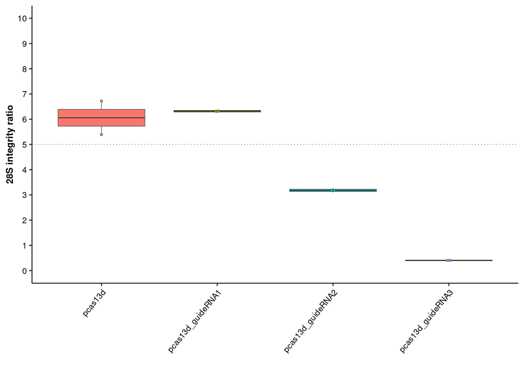

```r
plot_28s_lr <- rRNA_analysis_table_maxes %>%
  ggplot(aes(x= group, y = ratio_28S_long, fill = group)) +
  geom_boxplot(outlier.shape = NA, show.legend = FALSE, linewidth = 0.2)+
  geom_dotplot(binaxis = "y", stackdir = "center", dotsize = 0.3, show.legend = FALSE, stroke = 0.3)+
  xlab("")+
  geom_hline(yintercept = 5, linetype = 3, linewidth = 0.15)+
  scale_y_continuous(limits = c(0,10), breaks = seq(0, 10, by = 1))+
  ylab("28S integrity ratio")+
  theme(axis.text.x = element_text(size=8, angle=50, hjust = 1, color = 'black'),
        axis.text.y = element_text(size=8, color = 'black'),
        axis.title.y = element_text(face = "bold",size=9, color = 'black'),
        legend.title = element_blank(),
        panel.grid.major = element_blank(), panel.grid.minor = element_blank(),
        panel.background = element_blank(),
        axis.line = element_line(color = "black", linewidth = 0.4))
plot_28s_lr
```